# Concrete Strength Prediction - Project_Prabhu_30Oct2020_prab

## Objective / Goal

To predict the concrete strength using the data available in file "concrete.csv". Apply feature engineering and model tuning to obtain 85% to 95% accuracy.

## Data set

file : concrete.csv file

## Attribute Information

Concrete data :Input and Output variables

1. cement : Cement (cement) quantitative kg in a m3 mixture -- Input Variable
2. slag : Blast Furnace Slag (slag) quantitative kg in a m3 mixture -- Input Variable
3. ash : Fly Ash (ash) quantitative kg in a m3 mixture -- Input Variable
4. water : Water(water) quantitative kg in a m3 mixture -- Input Variable
5. superplastic : Superplasticizer (superplastic) quantitative kg in a m3 mixture -- Input Variable
6. coarseagg : Coarse Aggregate (coarseagg) quantitative kg in a m3 mixture -- Input Variable
7. fineagg : Fine Aggregate (fineagg) quantitative kg in a m3 mixture -- Input Variable
8. age : Age(age) quantitative Day (1~365) -- Input Variable
9. strength : Concrete compressive strength(strength) quantitative MPa -- Output Variable

```python
import warnings
warnings.filterwarnings('ignore')
```

```python
## importing libaries

import numpy as np
import pandas as pd
import seaborn as sns
from matplotlib import pyplot as plt
%matplotlib inline
import statsmodels.api as sm
from sklearn.model_selection import train_test_split
from sklearn.linear_model import LinearRegression
from sklearn.metrics import mean_squared_error
from sklearn.model_selection import train_test_split
from sklearn.tree import DecisionTreeClassifier
from sklearn import metrics
from sklearn.metrics import accuracy_score,f1_score,recall_score,precision_score, confusion_matrix


from sklearn.feature_extraction.text import CountVectorizer
```

```python
# importing data
df = pd.read_csv("concrete.csv")
df.head()      # used to see top 5 rows of the dataset
```

|  | cement | slag | ash | water | superplastic | coarseagg | fineagg | age | strength |
| --- | --- | --- | --- | --- | --- | --- | --- | --- | --- |
| 0 | 141.3 | 212.0 | 0.0 | 203.5 | 0.0 | 971.8 | 748.5 | 28 | 29.89 |
| 1 | 168.9 | 42.2 | 124.3 | 158.3 | 10.8 | 1080.8 | 796.2 | 14 | 23.51 |
| 2 | 250.0 | 0.0 | 95.7 | 187.4 | 5.5 | 956.9 | 861.2 | 28 | 29.22 |
| 3 | 266.0 | 114.0 | 0.0 | 228.0 | 0.0 | 932.0 | 670.0 | 28 | 45.85 |
| 4 | 154.8 | 183.4 | 0.0 | 193.3 | 9.1 | 1047.4 | 696.7 | 28 | 18.29 |

## A) Exploratory Data Analysis

### 1. Univariate Analysis

```python
df.info()
```

```
<class 'pandas.core.frame.DataFrame'>
RangeIndex: 1030 entries, 0 to 1029
Data columns (total 9 columns):
 #   Column        Non-Null Count  Dtype
---  ------        --------------  -----
 0   cement        1030 non-null   float64
 1   slag          1030 non-null   float64
 2   ash           1030 non-null   float64
 3   water         1030 non-null   float64
 4   superplastic  1030 non-null   float64
 5   coarseagg     1030 non-null   float64
 6   fineagg       1030 non-null   float64
 7   age           1030 non-null   int64
 8   strength      1030 non-null   float64
dtypes: float64(8), int64(1)
memory usage: 72.5 KB
```

```python
df.describe()
```

|  | cement | slag | ash | water | superplastic | coarseagg | fineagg | age | strength |
| --- | --- | --- | --- | --- | --- | --- | --- | --- | --- |
| count | 1030.000000 | 1030.000000 | 1030.000000 | 1030.000000 | 1030.000000 | 1030.000000 | 1030.000000 | 1030.000000 | 1030.000000 |
| mean | 281.167864 | 73.895825 | 54.188350 | 181.567282 | 6.204660 | 972.918932 | 773.580485 | 45.662136 | 35.817961 |
| std | 104.506364 | 86.279342 | 63.997004 | 21.354219 | 5.973841 | 77.753954 | 80.175980 | 63.169912 | 16.705742 |
| min | 102.000000 | 0.000000 | 0.000000 | 121.800000 | 0.000000 | 801.000000 | 594.000000 | 1.000000 | 2.330000 |
| 25% | 192.375000 | 0.000000 | 0.000000 | 164.900000 | 0.000000 | 932.000000 | 730.950000 | 7.000000 | 23.710000 |
| 50% | 272.900000 | 22.000000 | 0.000000 | 185.000000 | 6.400000 | 968.000000 | 779.500000 | 28.000000 | 34.445000 |
| 75% | 350.000000 | 142.950000 | 118.300000 | 192.000000 | 10.200000 | 1029.400000 | 824.000000 | 56.000000 | 46.135000 |
| max | 540.000000 | 359.400000 | 200.100000 | 247.000000 | 32.200000 | 1145.000000 | 992.600000 | 365.000000 | 82.600000 |

```python
df.describe().T
```

|  | count | mean | std | min | 25% | 50% | 75% | max |
| --- | --- | --- | --- | --- | --- | --- | --- | --- |
| cement | 1030.0 | 281.167864 | 104.506364 | 102.00 | 192.375 | 272.900 | 350.000 | 540.0 |
| slag | 1030.0 | 73.895825 | 86.279342 | 0.00 | 0.000 | 22.000 | 142.950 | 359.4 |
| ash | 1030.0 | 54.188350 | 63.997004 | 0.00 | 0.000 | 0.000 | 118.300 | 200.1 |
| water | 1030.0 | 181.567282 | 21.354219 | 121.80 | 164.900 | 185.000 | 192.000 | 247.0 |
| superplastic | 1030.0 | 6.204660 | 5.973841 | 0.00 | 0.000 | 6.400 | 10.200 | 32.2 |
| coarseagg | 1030.0 | 972.918932 | 77.753954 | 801.00 | 932.000 | 968.000 | 1029.400 | 1145.0 |
| fineagg | 1030.0 | 773.580485 | 80.175980 | 594.00 | 730.950 | 779.500 | 824.000 | 992.6 |
| age | 1030.0 | 45.662136 | 63.169912 | 1.00 | 7.000 | 28.000 | 56.000 | 365.0 |
| strength | 1030.0 | 35.817961 | 16.705742 | 2.33 | 23.710 | 34.445 | 46.135 | 82.6 |

#### Some values below min or 25% or 50% are "0" they are ok as ash, slag , super plastic may not be mixed in final cement

#### So "0" is not an error value

```python
df.skew()
```

```
cement          0.509481
slag            0.800717
ash             0.537354
water           0.074628
superplastic    0.907203
coarseagg      -0.040220
fineagg        -0.253010
age             3.269177
strength        0.416977
dtype: float64
```

```python
df.nunique()
```

```
cement          278
slag            185
ash             156
water           195
superplastic    111
coarseagg       284
fineagg         302
age              14
strength        845
dtype: int64
```

```python
df.isnull().sum()  #check for null Values
```

```
cement          0
slag            0
ash             0
water           0
superplastic    0
coarseagg       0
fineagg         0
age             0
strength        0
dtype: int64
```

### 2. Bi-variate Analysis

Bi-variate analysis between the predictor variables and between the predictor variables and target column. Comment on your findings in terms of their relationship and degree of relation if any. Visualize the analysis using boxplots and pair plots, histograms, or density curves. (10marks)

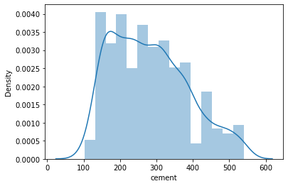

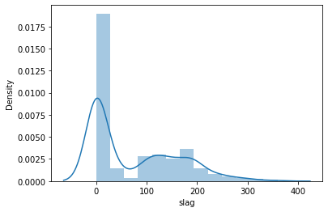

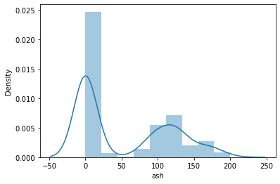

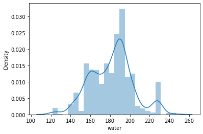

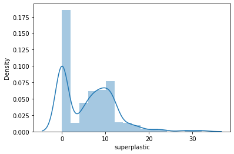

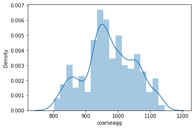

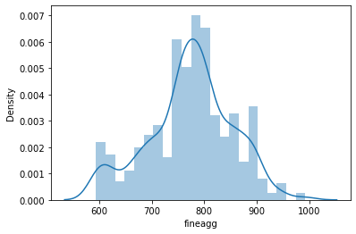

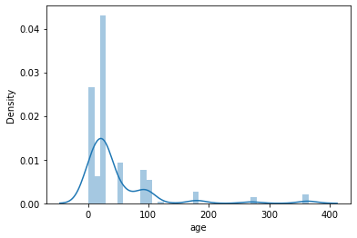

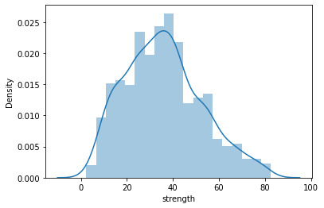

```python
# Plot all columns to look at their distributions

import seaborn as sns
for i in df.columns:
    sns.distplot(df[i])
    plt.show()
```

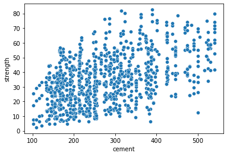

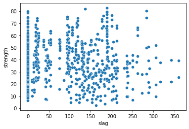

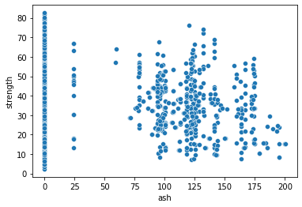

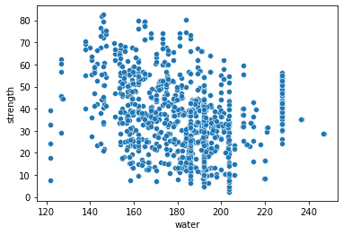

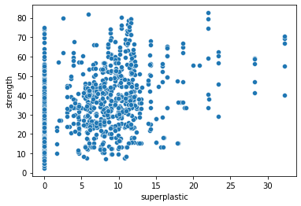

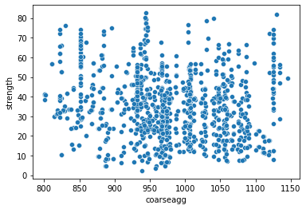

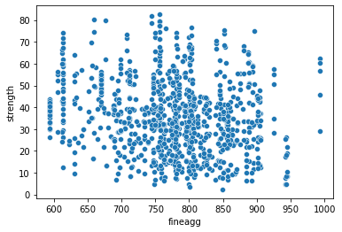

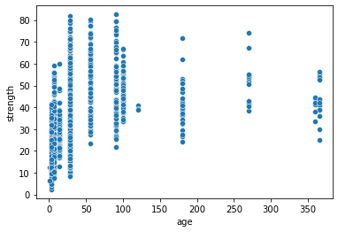

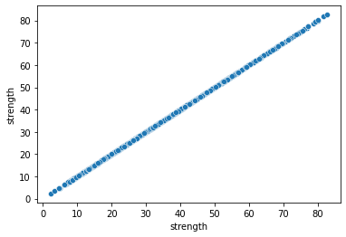

```python
#Bivariate Scatterplot of Strength with all the features
for i in df.columns:
    sns.scatterplot(x = df[i], y = df['strength'])
    plt.show()
```

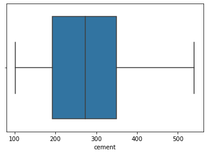

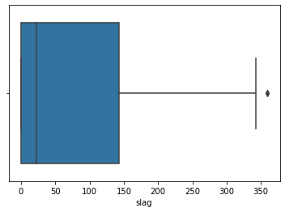

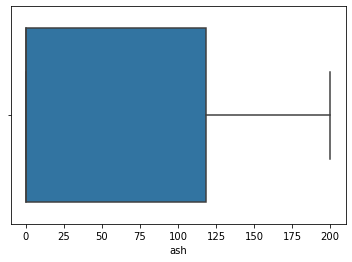

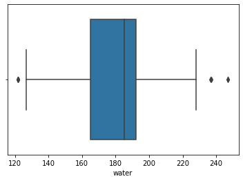

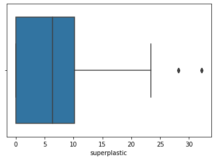

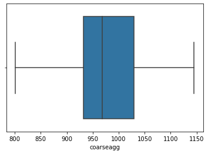

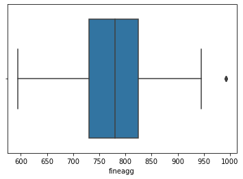

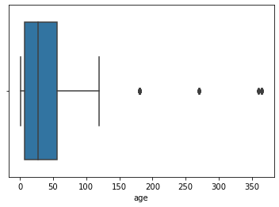

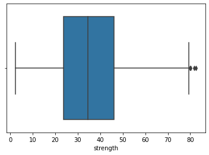

```python
#Checking for outliers using boxplots
for i in df.columns:
    sns.boxplot(df[i])
    plt.show()
```

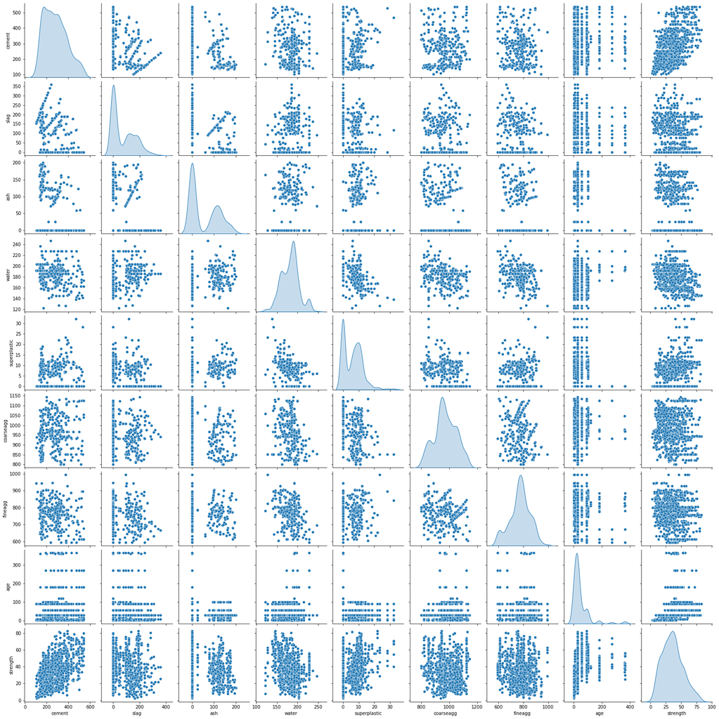

```python
sns.pairplot(df,diag_kind='kde')
plt.show()
```

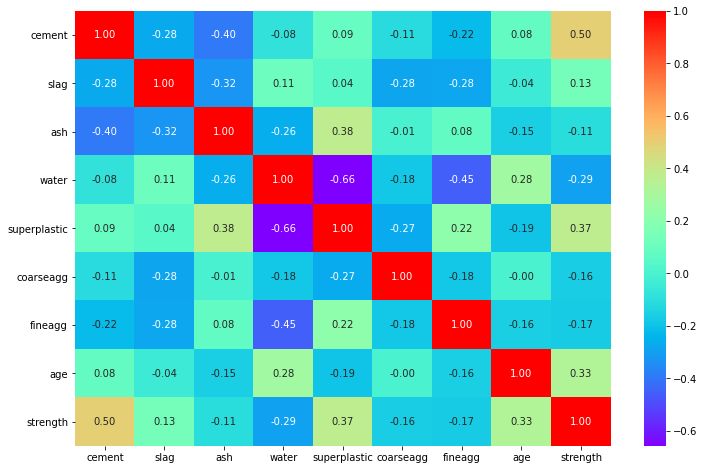

```python
# Looking for correlation Heatmap  ---- Below plot and other plots shows Cement and Strength has highest correlation 0.5
plt.figure(figsize=(12,8))
sns.heatmap(df.corr(),annot=True,fmt='.2f',cmap='rainbow', )
plt.show()
```

```python
# Lets check for highly correlated variables
# Below results and correlation matrix shows there are no correlation values above 0.8 and below -0.8
cor= df.corr()
cor.loc[:,:] = np.tril(cor,k=-1)
cor=cor.stack()
cor[(cor > 0.8) | (cor< -0.8)]
```

```
Series([], dtype: float64)
```

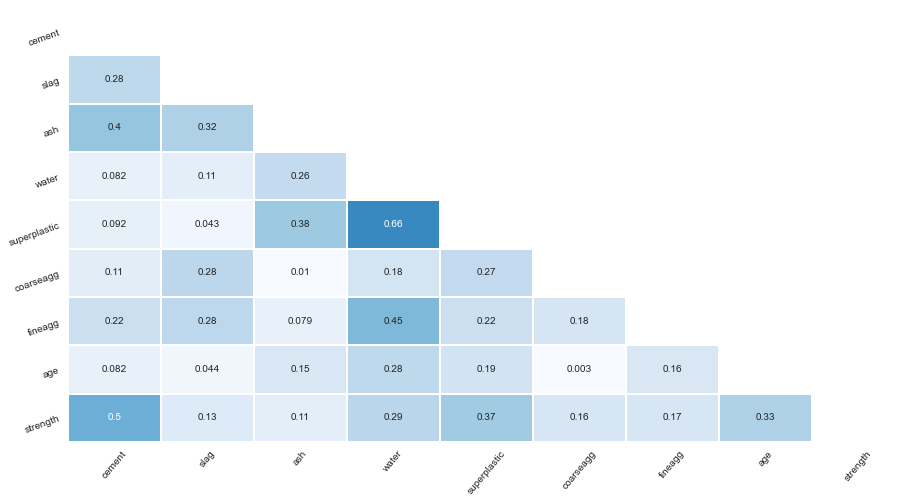

```python
corr = abs(df.corr()) # correlation matrix -- another style
lower_triangle = np.tril(corr, k = -1)  # select only the lower triangle of the correlation matrix
mask = lower_triangle == 0  # to mask the upper triangle in the following heatmap

plt.figure(figsize = (15,8))  # setting the figure size
sns.set_style(style = 'white')  # Setting it to white so that we do not see the grid lines
sns.heatmap(lower_triangle, center=0.5, cmap= 'Blues', annot= True, xticklabels = corr.index, yticklabels = corr.columns,
            cbar= False, linewidths= 1, mask = mask)   # Da Heatmap
plt.xticks(rotation = 50)   # Aesthetic purposes
plt.yticks(rotation = 20)   # Aesthetic purposes
plt.show()
```

```python
# to look at the target variable "strength" to understand how the data is distributed amongst the varous
df.groupby(["strength"]).mean()
```

| strength | cement | slag | ash | water | superplastic | coarseagg | fineagg | age |
| --- | --- | --- | --- | --- | --- | --- | --- | --- |
| 2.33 | 108.3 | 162.4 | 0.0 | 203.5 | 0.0 | 938.2 | 849.0 | 3.0 |
| 3.32 | 122.6 | 183.9 | 0.0 | 203.5 | 0.0 | 958.2 | 800.1 | 3.0 |
| 4.57 | 102.0 | 153.0 | 0.0 | 192.0 | 0.0 | 887.0 | 942.0 | 3.0 |
| 4.78 | 153.0 | 102.0 | 0.0 | 192.0 | 0.0 | 888.0 | 943.1 | 3.0 |
| 4.83 | 141.3 | 212.0 | 0.0 | 203.5 | 0.0 | 971.8 | 748.5 | 3.0 |
| ... | ... | ... | ... | ... | ... | ... | ... | ... |
| 79.40 | 389.9 | 189.0 | 0.0 | 145.9 | 22.0 | 944.7 | 755.8 | 56.0 |
| 79.99 | 540.0 | 0.0 | 0.0 | 162.0 | 2.5 | 1040.0 | 676.0 | 28.0 |
| 80.20 | 323.7 | 282.8 | 0.0 | 183.8 | 10.3 | 942.7 | 659.9 | 56.0 |
| 81.75 | 315.0 | 137.0 | 0.0 | 145.0 | 5.9 | 1130.0 | 745.0 | 28.0 |
| 82.60 | 389.9 | 189.0 | 0.0 | 145.9 | 22.0 | 944.7 | 755.8 | 91.0 |

845 rows × 8 columns

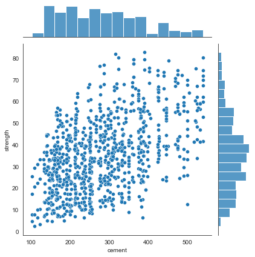

```python
sns.jointplot(df['cement'], df['strength']);
```

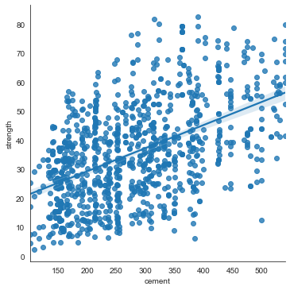

```python
# lmplot is for linear regression models
sns.lmplot(x="cement", y="strength", data=df);
```